# GradientMetrics-Vignette

## Exploratory analysis.

This is a first approach to the problem presented as a homework assignment.

The problem states that there is a add campaign, which has two parts. The experiment and the survey. The goal is to assess properly the results of the campaign and to make recommendation in regard which option is best to move forward.

The analysis must give insight about this.

First, let's define the function:

**ballon_plot('answer',*other*,experimient_data)**

This constructs a Nx4 matrix, for $N$ different values the variable can take, and 4 different levels of the answer. The elements are the sum of answers for each level. Finally, plots a ballon plot of the same grid, in which the size of the plot corresponds with the value of the element. All the plots, corresponding to the stratified sample of the experimient data are stored in *plots_ball* list.

Let's examine this plot for each varible of the experimient.

### **Tasks**

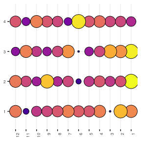

```r
plots_ball[[1]]+coord_flip()+
theme(axis.text.x = element_text(angle = 90, hjust=1),text = element_text(size=8))
```

Here we can see that the tasks $1$ and $6$ have the highest number of high answers. And $12$ has the highest number of low answers. The visual analysis, then, would suggest a weak correlation between $tasks$ and $answer$ since only $3$ out of $12$ tasks have a noticeable effect.

The Cramer's V for this element is 0 which means the correlation between the answer and the response is small, which make sense given the visual analysis.

There is no specification about what the variable means, so there are no further comments about this.

### **Duration**

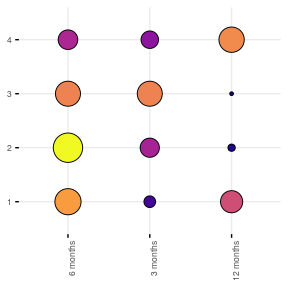

```r
plots_ball[[2]]+coord_flip()+
theme(axis.text.x = element_text(angle = 90, hjust=1),text = element_text(size=8))
```

### **Offer**

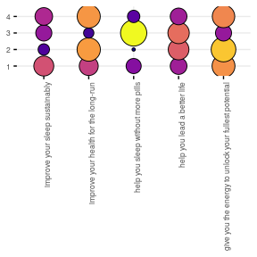

```r
plots_ball[[3]]+coord_flip()+
theme(axis.text.x = element_text(angle = 90, hjust=1),text = element_text(size=8))
```

Cramer's V for this element is 0.0161 which would suggest no association between this variable and the answer. Which makes sense since the visual aid is telling us that only one of the options seems slightly correlated with the answer.

## **Outcome**

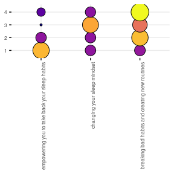

```r
plots_ball[[4]]+coord_flip()+
theme(axis.text.x = element_text(angle = 90, hjust=1),text = element_text(size=8))
```

Here, the outcome which seems correlated with a high score is "breaking habits" and "changing mindset", in both cases the meaning of the phrase is to make a change, in how you do things, instead on who you are (which I would associate to "empowering you..."), which seems mostly random.

The Cramer's V for this element is 0.0178, which is smaller than expected given the visual analysis, but still greater than zero, which means this could be a meaningful predictor.

## **Price**

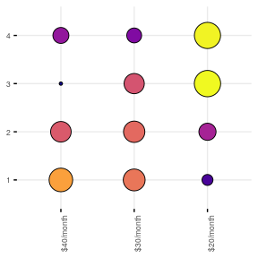

```r
plots_ball[[5]]+coord_flip()+
theme(axis.text.x = element_text(angle = 90, hjust=1),text = element_text(size=8))
```

If I knew nothing of the data, I would say that lower prices are more likely to get a high answer. And the visual analysis confirms this.

The Cramer's V for this element is 0.0877, which means this is the stronger predictor one would expect to encounter while modelling. ## **RTB**

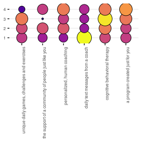

```r
plots_ball[[6]]+coord_flip()+
theme(axis.text.x = element_text(angle = 90, hjust=1),text = element_text(size=8))
```

Here, a specialized program would seem to indicate a better chance of giving a high score, the same is the case when we are talking about a "therapy", and people seem not really comfortable receiving a message every day from a coach.

Cramer's V is 0.0235, which makes this the second highest correlated variable so far, just behind price.

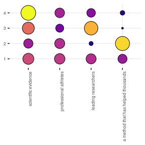

```r
plots_ball[[7]]+coord_flip()+
theme(axis.text.x = element_text(angle = 90, hjust=1),text = element_text(size=8))
```

About the proof, if you tell people that other people use it (whether it's thousands or professional athletes), they seem less likely to give a high score, but if you tell them that it is scientifically proven they are more likely to recommend it.

Cramer's V is 0.0173, which is about the same as the previous.

## Variance Analysis

On the other hand, I'll make sure that the distribution of different options doesn't have a pattern (this means that the experiment was, indeed, random). To do that I'll do a variance analysis, but since we are dealing with mostly categorical data, PCA is not the best suited tool, I'll use a Multi-Correspondence Analysis (MCA) which is like a Principal Component Analysis but it deals better with the one-hot encoding of the categorical variables.

The function *get_MCA_plot(experimient)* takes as input the experimient data, makes the one hot encoding, performs the MCA analysis and returns a plot with the explain variance of each "principal component"

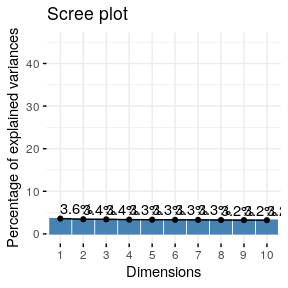

```r
get_MCA_plot(experiment)
```

It seems that the explained variance is evenly (uniformly) distributed, with and without adding the "answer". So it is quite random.

## Modelling

**The Survey Data**

To begin the modelling, one could start by inquiring the data demographic data about potential groups of people, to do that, I'll use a K-Means clustering.

The first step towards clustering is to mesaure the distances between points, for that I'll use the euclidean distance.
$$d(p,q) = \sqrt{\sum_{i=1}^n(q_i-p_i)^2}$$
Which in this case is the dummified version of the demographic variables. This produces a $N\times N$ matrix with the distance from each point to the rest.

With this distance I'll create two new variables:

- Cluster (K-Means)
- Individuality (Principal Component Analysis)

*Cluster*

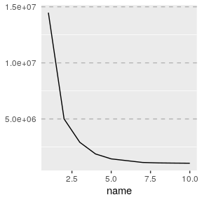

```r
kmplot+theme_cleveland()
```

Using the "elbow" method, the optimal $K \in \{3,4,5\}$. Since posterior analysis indicates that 5 groups are better for prediction, I'll keep that $k$.

*Individuality*

For this I'll use the distance matrix to get the first principal component of the variance of the distance, a mesaure which I'll call "Individuality" of the respondant.

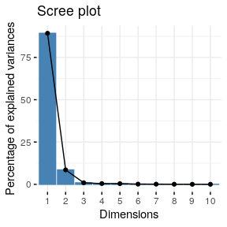

```r
pca_plot
```

*Variable Selection*

The survey data gives a glance of the profiles of the clients. But since there are so many, first it is necessary to reduce the variables to use. For which I'll use Cramer's V systematically, to know the intercorrelation between all of these variables, on the stratified sample mentioned earlier.

To be selected a variable must comply with 3 criteria:

- More than 1 unique value.
- Cramer's V greater than 0.2
- Be in the set of variables of interest (of the experiments)

The 0.2 is an arbitrary value (functions as a hyperparameter) which can also be estimated programmatically, which can be done in a second stage. To do that is that the function *variable_selection_cramerV()* is about.

First, it is necessary to join the experiment data with the survey data and take the stratified sample. Next it calculates Cramer's for each element and filters according to the second parameter,which here is $0.2$, and mentioned criteria.

```r
knitr::opts_chunk$set(fig.width=14, fig.height=14)
knitr::kable(variable_selection_cramerV(survey_experiment,0.2))
```

| variable | names | x |
| --- | --- | --- |
| d_employment | Cramer V | 0.25150 |
| d_parent | Cramer V | 0.40260 |
| d_urban | Cramer V | 0.22370 |
| duration | Cramer V | 0.00000 |
| interest_coach | Cramer V | 0.37950 |
| interst_cbt | Cramer V | 0.33830 |
| m1_philosophy_2 | Cramer V | 0.23210 |
| m1_philosophy_5 | Cramer V | 0.22310 |
| m1_philosophy_6 | Cramer V | 0.25110 |
| m2_attitudes_5 | Cramer V | 0.20630 |
| offer | Cramer V | 0.00000 |
| outcome | Cramer V | 0.00000 |
| past_coach | Cramer V | 0.28350 |
| pca1 | Cramer V | 0.49760 |
| price | Cramer V | 0.09754 |
| rtb | Cramer V | 0.01993 |
| s_age | Cramer V | 0.28170 |
| social_proof | Cramer V | 0.01025 |
| task | Cramer V | 0.00000 |
| weights | Cramer V | 0.46760 |

**Cluster Characterization**

Given 5 groups, let's see if there is some insight which might help us understand our population.

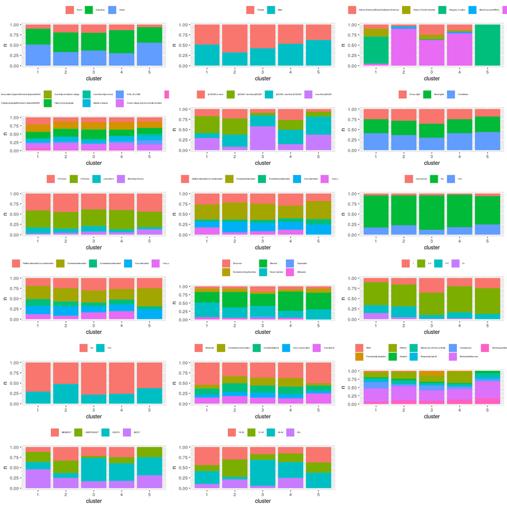

```r
gridExtra::grid.arrange(grobs=om_plots,nrow=6)
```

Lets see the composition of each group, for each relevant variable.

First, the philosophy and attitudes variables.

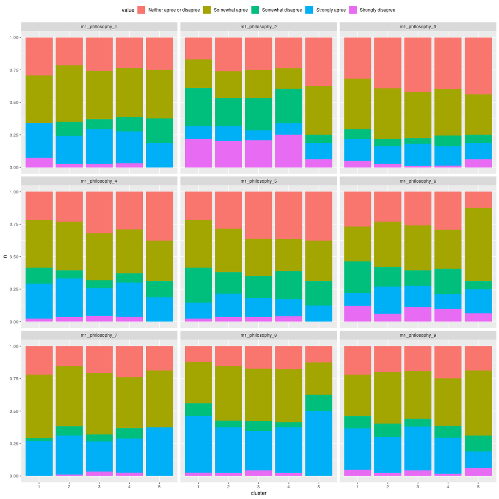

```r
m1_philosophy_plot+ theme(legend.position="top")
```

Let's remember first which were the questions to talk about our groups:

```r
m1_philosophy[,1:9] %>% map_chr(attr_getter("label"))
```

```
##                                                                                                                                                                                          m1_philosophy_1
##                                                          "To what extent do you agree or disagree with each of the following statements? - I rely on medical science to make decisions about my health."
##                                                                                                                                                                                          m1_philosophy_2
##                                                             "To what extent do you agree or disagree with each of the following statements? - I am skeptical that scientific research benefits society."
##                                                                                                                                                                                          m1_philosophy_3
##                                                                "To what extent do you agree or disagree with each of the following statements? - Approaches used by western medicine are usually right."
##                                                                                                                                                                                          m1_philosophy_4
##                                                 "To what extent do you agree or disagree with each of the following statements? - I care about the environmental sustainability of products that I use."
##                                                                                                                                                                                          m1_philosophy_5
## "To what extent do you agree or disagree with each of the following statements? - I make choices about the products I use based on the immediate health benefits rather than long-term health benefits."
##                                                                                                                                                                                          m1_philosophy_6
##                                                      "To what extent do you agree or disagree with each of the following statements? - I regularly try new products that are known for health benefits."
##                                                                                                                                                                                          m1_philosophy_7
##                                                     "To what extent do you agree or disagree with each of the following statements? - I enjoy learning about how the things I consume impact my health."
##                                                                                                                                                                                          m1_philosophy_8
##                                                                        "To what extent do you agree or disagree with each of the following statements? - Personal wellness is one of my top priorities."
##                                                                                                                                                                                          m1_philosophy_9
##  "To what extent do you agree or disagree with each of the following statements? - I am skeptical about the value of health supplements that are not regulated by the Food & Drug Administration (FDA)."
```

Ok, what do we have here:

- Questions 1-3 are about confidence in science.
- Question 4 is enviromental concerns
- Question 5-8 is about health.
- Question 9 is the state and regulations.

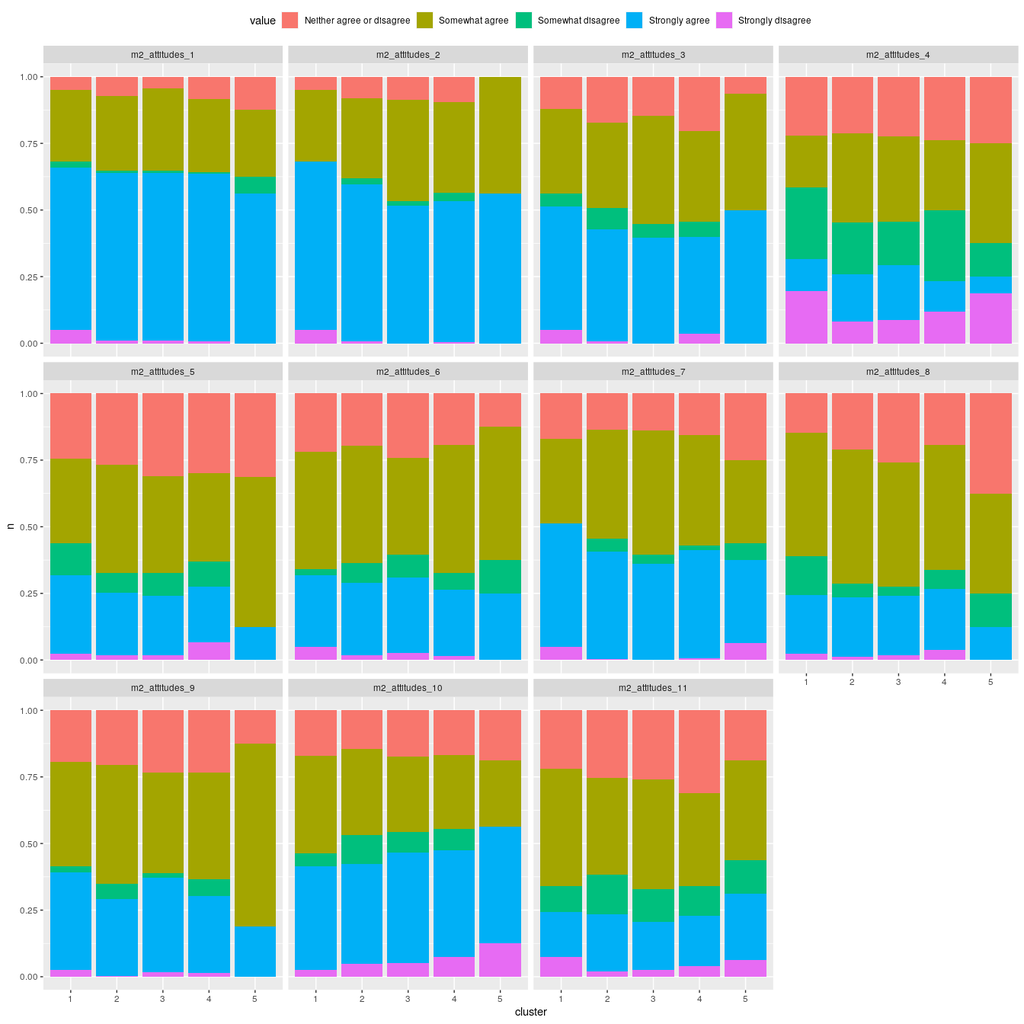

```r
m2_attitudes_plot+ theme(legend.position="top")
```

Here, we have:

```r
knitr::opts_chunk$set(fig.width=4, fig.height=4)
m2_attitudes[,1:9] %>% map_chr(attr_getter("label"))
```

```
##                                                                                                                                                                                         m2_attitudes_1
##                                                    "To what extent do you agree or disagree with each of the following statements? - Getting high quality sleep is important for my long-term health."
##                                                                                                                                                                                         m2_attitudes_2
##                                                                        "To what extent do you agree or disagree with each of the following statements? - Getting better sleep would improve my focus."
##                                                                                                                                                                                         m2_attitudes_3
##                                                                            "To what extent do you agree or disagree with each of the following statements? - My mood is highly dependent on my sleep."
##                                                                                                                                                                                         m2_attitudes_4
##                                                                      "To what extent do you agree or disagree with each of the following statements? - I have given up on getting good quality sleep."
##                                                                                                                                                                                         m2_attitudes_5
## "To what extent do you agree or disagree with each of the following statements? - I am looking for a personalized solution to improve my sleep rather than a generic solution that applies to anyone."
##                                                                                                                                                                                         m2_attitudes_6
##                                     "To what extent do you agree or disagree with each of the following statements? - I do my best to maintain my body’s circadian rhythm (Your natural sleep cycle)."
##                                                                                                                                                                                         m2_attitudes_7
##                                      "To what extent do you agree or disagree with each of the following statements? - It is important to me that I get enough uninterrupted deep sleep (REM cycles)."
##                                                                                                                                                                                         m2_attitudes_8
##                                                                                 "To what extent do you agree or disagree with each of the following statements? - My sleep quality changes over time."
##                                                                                                                                                                                         m2_attitudes_9
##                                                       "To what extent do you agree or disagree with each of the following statements? - Consistent, high-quality sleep requires sticking to routines."
```

_**RandomForest Multiclassfication**

Finally, we can have a preliminary model of the answer which has a 67% accuracy on a test set using a randomForest model.

randomForest allows us to know which are the best discriminatory variables.

**Importance of Variables of interest (of experimient)**

```r
knitr::kable(vdf_experiment)
```

| X1 | X2 | X3 | X4 | Variables |
| --- | --- | --- | --- | --- |
| 3.6925699 | 4.1805938 | 6.282813 | 5.3323696 | duration |
| -1.2874513 | 1.7297259 | 1.566142 | -0.4069726 | offer |
| 1.5438075 | 0.3391769 | 2.117856 | 6.5735494 | outcome |
| 10.8730112 | 23.2348758 | 15.130753 | 7.3822893 | price |
| -0.2114713 | -0.9225814 | 1.598151 | 0.7543211 | rtb |
| -2.9590988 | -3.1275464 | 1.113838 | 0.4837008 | social_proof |
| -3.2803268 | -0.7508627 | -5.585046 | -6.7577104 | task |

____Importance of Variables of survey___

Here, we can see that every of the survey variables are mostly similarly important

```r
vdf_survay
```

```
## # A tibble: 14 x 5
##       X1    X2    X3    X4 Variables
##    <dbl> <dbl> <dbl> <dbl> <chr>
##  1  48.1  48.6  36.5  51.7 d_employment
##  2  25.1  30.9  22.0  26.0 d_parent
##  3  27.5  32.8  24.3  38.3 d_urban
##  4  42.2  47.4  40.1  47.3 interest_coach
##  5  39.1  44.8  33.0  45.8 interst_cbt
##  6  39.9  47.5  36.6  40.6 m1_philosophy_2
##  7  38.8  41.3  32.0  34.2 m1_philosophy_5
##  8  36.7  45.2  32.9  35.5 m1_philosophy_6
##  9  36.4  40.8  35.4  29.5 m2_attitudes_5
## 10  23.6  30.3  23.3  32.5 past_coach
## 11  39.4  50.8  34.7  39.9 pca1
## 12  36.7  46.6  32.8  40.0 s_age
## 13  29.6  48.4  33.3  35.4 weights
## 14  21.3  29.1  22.9  22.3 cluster
```

**Confusion Matrix**

And an exam of the confusion matrix applied to the test set tells us that the model is fairly good in classification, and even the mistakes are close to the real value. When the reference is 1, the model is highly likely to predict 1 or, to a lesser extent, 2 and almost never predicts 3 or 4, the same thing happens when the reference is 4 (it almost never predicts 1). When it comes to 2 and 3, this also happens, but since they are not extreme values, the model confuses it more (albeit not much)

```r
caret::confusionMatrix(predict(rfm_reg,test),as.factor(test$answer))
```

```
## Confusion Matrix and Statistics
##
##           Reference
## Prediction   1   2   3   4
##          1 318  48  18   2
##          2  44 226  54  14
##          3  16  70 198  82
##          4   7  32 117 254
##
## Overall Statistics
##
##                Accuracy : 0.664
##                  95% CI : (0.6395, 0.6879)
##     No Information Rate : 0.258
##     P-Value [Acc > NIR] : < 2.2e-16
##
##                   Kappa : 0.5522
##
##  Mcnemar's Test P-Value : 0.005451
##
## Statistics by Class:
##
##                      Class: 1 Class: 2 Class: 3 Class: 4
## Sensitivity            0.8260   0.6011   0.5116   0.7216
## Specificity            0.9390   0.9004   0.8491   0.8641
## Pos Pred Value         0.8238   0.6686   0.5410   0.6195
## Neg Pred Value         0.9399   0.8709   0.8333   0.9101
## Prevalence             0.2567   0.2507   0.2580   0.2347
## Detection Rate         0.2120   0.1507   0.1320   0.1693
## Detection Prevalence   0.2573   0.2253   0.2440   0.2733
## Balanced Accuracy      0.8825   0.7507   0.6803   0.7929
```

The randomForest shows promising results and it is better suited for multicategory output. But it doesn't tell us the direction of each one. Since the answer is numeric, we can run a linear regression on the data to get the value of the coefficients.

**The linear model**

What the previous analysis provided was insight about which variables are important, but it had little to say about what course of action to recommend. The linear model has that benefit, it provides a sign (positive or negative) for each value the variable can take, and it is possible to descart some values if they are proven insignificant.

```r
sjPlot::tab_model(linear_model)
```

|  | answer |  |  |
| --- | --- | --- | --- |
| Predictors | Estimates | CI | p |
| (Intercept) | 3.79 | 3.33 – 4.26 | **<0.001** |
| Which of the following best describes your current employment status?: Working part time now | -0.13 | -0.21 – -0.05 | **0.001** |
| Which of the following best describes your current employment status?: Temporarily laid off | -0.27 | -0.41 – -0.12 | **<0.001** |
| Which of the following best describes your current employment status?: Unemployed | -0.17 | -0.26 – -0.07 | **<0.001** |
| Which of the following best describes your current employment status?: Retired | -0.22 | -0.32 – -0.12 | **<0.001** |
| Which of the following best describes your current employment status?: Permanently disabled | -0.15 | -0.28 – -0.02 | **0.022** |
| Which of the following best describes your current employment status?: Taking care of home or family | -0.33 | -0.43 – -0.23 | **<0.001** |
| Which of the following best describes your current employment status?: Student | -0.16 | -0.30 – -0.01 | **0.034** |
| Which of the following best describes your current employment status?: Other | -0.27 | -0.55 – 0.01 | 0.057 |
| Are you currently the parent or guardian of a child under 18 years of age?: No | -0.22 | -0.29 – -0.16 | **<0.001** |
| Would you describe the area in which you live as urban,suburban,or rural?: Suburban(An area that is residential and on the outskirts of a city) | -0.19 | -0.25 – -0.14 | **<0.001** |
| Would you describe the area in which you live as urban,suburban,or rural?: Rural(An area that is outside of town or city and has a small population) | -0.14 | -0.22 – -0.06 | **0.001** |
| duration3 months | -0.01 | -0.07 – 0.05 | 0.685 |
| duration6 months | -0.04 | -0.10 – 0.02 | 0.184 |
| How interested are you in working with a professional coach to improve your health or well-being(e g,nutritionist,personal trainer,life coach,career coach,etc)?: Somewhat interested | -0.30 | -0.38 – -0.21 | **<0.001** |
| How interested are you in working with a professional coach to improve your health or well-being(e g,nutritionist,personal trainer,life coach,career coach,etc)?: Neither interested nor uninterested | -0.43 | -0.52 – -0.33 | **<0.001** |
| How interested are you in working with a professional coach to improve your health or well-being(e g,nutritionist,personal trainer,life coach,career coach,etc)?: Somewhat uninterested | -0.73 | -0.85 – -0.60 | **<0.001** |
| How interested are you in working with a professional coach to improve your health or well-being(e g,nutritionist,personal trainer,life coach,career coach,etc)?: Very uninterested | -0.89 | -1.03 – -0.75 | **<0.001** |
| How interested are you in trying cognitive behavioral therapy?: Somewhat interested | -0.08 | -0.16 – -0.01 | **0.029** |
| How interested are you in trying cognitive behavioral therapy?: Neither interested nor uninterested | -0.35 | -0.45 – -0.25 | **<0.001** |
| How interested are you in trying cognitive behavioral therapy?: Somewhat uninterested | -0.37 | -0.50 – -0.24 | **<0.001** |
| How interested are you in trying cognitive behavioral therapy?: Very uninterested | -0.51 | -0.67 – -0.35 | **<0.001** |
| To what extent do you agree or disagree with each of the following statements?-I am skeptical that scientific research benefits society: Somewhat disagree | 0.16 | 0.08 – 0.24 | **<0.001** |
| To what extent do you agree or disagree with each of the following statements?-I am skeptical that scientific research benefits society: Neither agree or disagree | 0.28 | 0.20 – 0.36 | **<0.001** |
| To what extent do you agree or disagree with each of the following statements?-I am skeptical that scientific research benefits society: Somewhat agree | 0.27 | 0.19 – 0.36 | **<0.001** |
| To what extent do you agree or disagree with each of the following statements?-I am skeptical that scientific research benefits society: Strongly agree | 0.26 | 0.16 – 0.36 | **<0.001** |
| To what extent do you agree or disagree with each of the following statements?-I make choices about the products I use based on the immediate health benefits rather than long-term health benefits: Som… | 0.20 | 0.04 – 0.36 | **0.013** |
| To what extent do you agree or disagree with each of the following statements?-I make choices about the products I use based on the immediate health benefits rather than long-term health benefits: Nei… | 0.23 | 0.07 – 0.38 | **0.005** |
| To what extent do you agree or disagree with each of the following statements?-I make choices about the products I use based on the immediate health benefits rather than long-term health benefits: Som… | 0.34 | 0.19 – 0.50 | **<0.001** |
| To what extent do you agree or disagree with each of the following statements?-I make choices about the products I use based on the immediate health benefits rather than long-term health benefits: Str… | 0.42 | 0.26 – 0.59 | **<0.001** |
| To what extent do you agree or disagree with each of the following statements?-I regularly try new products that are known for health benefits: Somewhat disagree | -0.17 | -0.29 – -0.05 | **0.006** |
| To what extent do you agree or disagree with each of the following statements?-I regularly try new products that are known for health benefits: Neither agree or disagree | -0.14 | -0.26 – -0.02 | **0.018** |
| To what extent do you agree or disagree with each of the following statements?-I regularly try new products that are known for health benefits: Somewhat agree | -0.03 | -0.14 – 0.09 | 0.662 |
| To what extent do you agree or disagree with each of the following statements?-I regularly try new products that are known for health benefits: Strongly agree | 0.05 | -0.08 – 0.18 | 0.453 |
| To what extent do you agree or disagree with each of the following statements?-I am looking for a personalized solution to improve my sleep rather than a generic solution that applies to anyone: Somew… | -0.06 | -0.24 – 0.13 | 0.562 |
| To what extent do you agree or disagree with each of the following statements?-I am looking for a personalized solution to improve my sleep rather than a generic solution that applies to anyone: Neith… | 0.01 | -0.16 – 0.19 | 0.888 |
| To what extent do you agree or disagree with each of the following statements?-I am looking for a personalized solution to improve my sleep rather than a generic solution that applies to anyone: Somew… | 0.04 | -0.13 – 0.22 | 0.631 |
| To what extent do you agree or disagree with each of the following statements?-I am looking for a personalized solution to improve my sleep rather than a generic solution that applies to anyone: Stron… | 0.03 | -0.15 – 0.21 | 0.761 |
| offerhelp you lead a better life | -0.07 | -0.15 – 0.00 | 0.054 |
| offerhelp you sleep without more pills | -0.05 | -0.12 – 0.03 | 0.197 |
| offerimprove your health for the long-run | -0.02 | -0.09 – 0.06 | 0.653 |
| offerimprove your sleep sustainably | -0.01 | -0.08 – 0.07 | 0.893 |
| outcomechanging your sleep mindset | -0.02 | -0.08 – 0.04 | 0.520 |
| outcomeempowering you to take back your sleep habits | -0.05 | -0.11 – 0.01 | 0.076 |
| Have you ever worked with a professional coach to improve your health or well-being(e g,nutritionist,personal trainer,life coach,career coach,etc)?: No | -0.22 | -0.28 – -0.15 | **<0.001** |
| Have you ever worked with a professional coach to improve your health or well-being(e g,nutritionist,personal trainer,life coach,career coach,etc)?: I am not sure | 0.11 | -0.03 – 0.25 | 0.126 |
| pca 1 | -0.00 | -0.00 – -0.00 | **0.006** |
| price$30/month | -0.20 | -0.26 – -0.14 | **<0.001** |
| price$40/month | -0.31 | -0.37 – -0.25 | **<0.001** |
| rtbcognitive behavioral therapy | 0.05 | -0.03 – 0.13 | 0.213 |
| rtbdaily text messages from a coach | -0.07 | -0.15 – 0.02 | 0.112 |
| rtbpersonalized, human coaching | 0.01 | -0.07 – 0.10 | 0.744 |
| rtbthe support of a community of people just like you | -0.03 | -0.12 – 0.05 | 0.435 |
| rtbunique daily games, challenges and exercises | -0.02 | -0.10 – 0.06 | 0.667 |
| s_age31-45 | -0.11 | -0.17 – -0.04 | **0.002** |
| s_age46-64 | -0.38 | -0.47 – -0.30 | **<0.001** |
| s_age65+ | -0.35 | -0.47 – -0.23 | **<0.001** |
| social_proofleading researchers | 0.03 | -0.04 – 0.09 | 0.453 |
| social_proofprofessional athletes | -0.02 | -0.09 – 0.04 | 0.498 |
| social_proofscientific evidence | 0.07 | 0.01 – 0.14 | **0.029** |
| task | 0.00 | -0.01 – 0.01 | 0.944 |
| weights | 0.10 | -0.12 – 0.31 | 0.383 |
| cluster: cluster 2 | -0.50 | -0.78 – -0.21 | **0.001** |
| cluster: cluster 3 | -0.42 | -0.64 – -0.21 | **<0.001** |
| cluster: cluster 4 | -0.46 | -0.71 – -0.20 | **0.001** |
| cluster: cluster 5 | 0.42 | 0.05 – 0.80 | **0.028** |
| Observations | 4500 |  |  |
| R<sup>2</sup> / R<sup>2</sup> adjusted | 0.488 / 0.481 |  |  |

First, let's check the residuals, to make sure they are normal with $0$ mean.

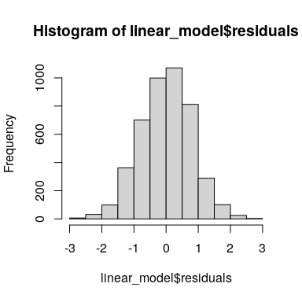

```r
hist(linear_model$residuals)
```

Finally, one could use the insights here provided to better the add campaign. To predict, I would use a variation of the randomForest model (a classification model) instead of a linear model (a regression model)

## Beyond the first glance:

**Linear Models for Cluster**

```r
sjPlot::tab_model(fitted_models_by_cluster$model)
```

|  | answer |  |  | answer |  |  | answer |  |  | answer |  |  | answer |  |  |
| --- | --- | --- | --- | --- | --- | --- | --- | --- | --- | --- | --- | --- | --- | --- | --- |
| Predictors | Estimates | CI | p | Estimates | CI | p | Estimates | CI | p | Estimates | CI | p | Estimates | CI | p |
| (Intercept) | 0.71 | -5.32 – 6.74 | 0.818 | 3.71 | 3.07 – 4.35 | **<0.001** | -1.99 | -9.14 – 5.16 | 0.586 | 2.04 | 0.06 – 4.02 | **0.044** | 1.88 | 0.97 – 2.79 | **<0.001** |
| Which of the following best describes your current employment status?: Working part time now | -0.81 | -1.75 – 0.13 | 0.093 | -0.14 | -0.27 – -0.01 | **0.041** | -0.15 | -0.43 – 0.14 | 0.318 | -0.18 | -0.31 – -0.06 | **0.004** | 0.58 | -0.33 – 1.50 | 0.216 |
| Which of the following best describes your current employment status?: Temporarily laid off | -0.81 | -1.98 – 0.35 | 0.172 | -0.73 | -1.08 – -0.39 | **<0.001** | -0.10 | -0.62 – 0.42 | 0.703 | -0.06 | -0.27 – 0.15 | 0.594 | 0.16 | -1.48 – 1.80 | 0.849 |
| Which of the following best describes your current employment status?: Unemployed | 2.47 | 0.43 – 4.51 | **0.019** | -0.01 | -0.17 – 0.14 | 0.853 | 0.05 | -0.18 – 0.28 | 0.689 | -0.52 | -0.69 – -0.36 | **<0.001** | -0.32 | -2.55 – 1.92 | 0.783 |
| Which of the following best describes your current employment status?: Retired | -0.28 | -1.82 – 1.27 | 0.727 | -0.41 | -0.64 – -0.17 | **0.001** | -0.26 | -0.55 – 0.04 | 0.086 | -0.22 | -0.35 – -0.09 | **0.001** |  |  |  |
| Which of the following best describes your current employment status?: Permanently disabled | -3.91 | -7.48 – -0.33 | **0.034** | 0.10 | -0.16 – 0.36 | 0.460 | -0.22 | -0.49 – 0.04 | 0.094 | -0.23 | -0.43 – -0.03 | **0.026** |  |  |  |
| Which of the following best describes your current employment status?: Taking care of home or family | -0.52 | -3.91 – 2.86 | 0.762 | -0.39 | -0.54 – -0.25 | **<0.001** | -0.01 | -0.44 – 0.42 | 0.968 | -0.44 | -0.61 – -0.27 | **<0.001** | 0.12 | -1.28 – 1.51 | 0.872 |
| Which of the following best describes your current employment status?: Student | -5.18 | -8.06 – -2.31 | **0.001** | -0.08 | -0.29 – 0.14 | 0.488 | -0.47 | -0.97 – 0.03 | 0.065 | -0.18 | -0.44 – 0.08 | 0.178 | -0.24 | -2.87 – 2.40 | 0.860 |
| Which of the following best describes your current employment status?: Other | -3.45 | -5.98 – -0.92 | **0.008** | -0.29 | -0.63 – 0.05 | 0.100 | 0.50 | -0.31 – 1.30 | 0.228 |  |  |  |  |  |  |
| Are you currently the parent or guardian of a child under 18 years of age?: No | 0.11 | -0.49 – 0.71 | 0.716 | -0.26 | -0.36 – -0.16 | **<0.001** | -0.24 | -0.48 – 0.00 | 0.054 | -0.29 | -0.40 – -0.17 | **<0.001** | 0.07 | -0.94 – 1.08 | 0.894 |
| Would you describe the area in which you live as urban,suburban,or rural?: Suburban(An area that is residential and on the outskirts of a city) | 1.61 | 0.32 – 2.90 | **0.015** | -0.26 | -0.35 – -0.16 | **<0.001** | -0.16 | -0.35 – 0.03 | 0.091 | -0.10 | -0.19 – -0.01 | **0.030** | 0.45 | -0.71 – 1.61 | 0.451 |
| Would you describe the area in which you live as urban,suburban,or rural?: Rural(An area that is outside of town or city and has a small population) | -1.90 | -4.05 – 0.25 | 0.085 | -0.29 | -0.41 – -0.17 | **<0.001** | 0.06 | -0.17 – 0.28 | 0.609 | -0.00 | -0.13 – 0.13 | 0.981 | 0.87 | -1.19 – 2.93 | 0.413 |
| duration3 months | -0.03 | -0.31 – 0.24 | 0.813 | -0.12 | -0.21 – -0.03 | **0.008** | 0.12 | -0.03 – 0.28 | 0.122 | 0.03 | -0.06 – 0.12 | 0.464 | 0.18 | -0.32 – 0.68 | 0.491 |
| duration6 months | -0.04 | -0.30 – 0.22 | 0.779 | -0.09 | -0.18 – 0.00 | 0.056 | 0.05 | -0.11 – 0.22 | 0.511 | -0.05 | -0.15 – 0.04 | 0.236 | 0.38 | -0.15 – 0.91 | 0.166 |
| How interested are you in working with a professional coach to improve your health or well-being(e g,nutritionist,personal trainer,life coach,career coach,etc)?: Somewhat interested | -0.68 | -1.98 – 0.63 | 0.311 | -0.21 | -0.32 – -0.09 | **<0.001** | -0.55 | -0.84 – -0.26 | **<0.001** | -0.50 | -0.65 – -0.35 | **<0.001** | 1.03 | -0.01 – 2.07 | 0.059 |
| How interested are you in working with a professional coach to improve your health or well-being(e g,nutritionist,personal trainer,life coach,career coach,etc)?: Neither interested nor uninterested | -2.29 | -4.43 – -0.14 | **0.038** | -0.34 | -0.48 – -0.20 | **<0.001** | -0.83 | -1.13 – -0.52 | **<0.001** | -0.53 | -0.69 – -0.36 | **<0.001** | 0.12 | -2.85 – 3.10 | 0.936 |
| How interested are you in working with a professional coach to improve your health or well-being(e g,nutritionist,personal trainer,life coach,career coach,etc)?: Somewhat uninterested | -3.76 | -5.72 – -1.79 | **<0.001** | -0.38 | -0.57 – -0.19 | **<0.001** | -1.11 | -1.55 – -0.66 | **<0.001** | -1.10 | -1.31 – -0.90 | **<0.001** |  |  |  |
| How interested are you in working with a professional coach to improve your health or well-being(e g,nutritionist,personal trainer,life coach,career coach,etc)?: Very uninterested | -4.08 | -7.52 – -0.63 | **0.022** | -0.71 | -0.96 – -0.46 | **<0.001** | -1.69 | -2.20 – -1.17 | **<0.001** | -0.98 | -1.19 – -0.77 | **<0.001** |  |  |  |
| How interested are you in trying cognitive behavioral therapy?: Somewhat interested | 0.99 | -0.48 – 2.46 | 0.188 | -0.20 | -0.31 – -0.09 | **<0.001** | 0.37 | 0.10 – 0.64 | **0.009** | 0.04 | -0.09 – 0.18 | 0.532 | -0.93 | -1.83 – -0.04 | **0.047** |
| How interested are you in trying cognitive behavioral therapy?: Neither interested nor uninterested | -1.35 | -4.01 – 1.31 | 0.322 | -0.48 | -0.64 – -0.33 | **<0.001** | 0.22 | -0.08 – 0.52 | 0.146 | -0.26 | -0.42 – -0.10 | **0.001** | -0.82 | -3.97 – 2.33 | 0.612 |
| How interested are you in trying cognitive behavioral therapy?: Somewhat uninterested | 0.72 | -1.68 – 3.13 | 0.556 | -0.51 | -0.73 – -0.29 | **<0.001** | 0.21 | -0.25 – 0.66 | 0.369 | -0.26 | -0.46 – -0.07 | **0.008** | -0.95 | -2.42 – 0.52 | 0.211 |
| How interested are you in trying cognitive behavioral therapy?: Very uninterested | 2.29 | -0.55 – 5.12 | 0.116 | -0.78 | -1.05 – -0.51 | **<0.001** | 0.78 | 0.26 – 1.31 | **0.004** | -0.38 | -0.63 – -0.14 | **0.002** |  |  |  |
| To what extent do you agree or disagree with each of the following statements?-I am skeptical that scientific research benefits society: Somewhat disagree | 1.26 | -0.32 – 2.84 | 0.119 | 0.03 | -0.09 – 0.16 | 0.611 | 0.41 | 0.13 – 0.69 | **0.004** | 0.20 | 0.08 – 0.31 | **0.001** |  |  |  |
| To what extent do you agree or disagree with each of the following statements?-I am skeptical that scientific research benefits society: Neither agree or disagree | -0.99 | -2.47 – 0.49 | 0.190 | 0.32 | 0.20 – 0.45 | **<0.001** | 0.48 | 0.19 – 0.76 | **0.001** | 0.16 | 0.04 – 0.28 | **0.010** | 0.59 | -1.06 – 2.24 | 0.485 |
| To what extent do you agree or disagree with each of the following statements?-I am skeptical that scientific research benefits society: Somewhat agree | -1.49 | -3.43 – 0.44 | 0.133 | 0.37 | 0.23 – 0.51 | **<0.001** | 0.59 | 0.33 – 0.86 | **<0.001** | 0.08 | -0.06 – 0.21 | 0.250 | 0.94 | -0.37 – 2.25 | 0.165 |
| To what extent do you agree or disagree with each of the following statements?-I am skeptical that scientific research benefits society: Strongly agree | -3.06 | -5.86 – -0.26 | **0.034** | 0.34 | 0.18 – 0.49 | **<0.001** | 0.37 | 0.00 – 0.74 | 0.050 | 0.18 | 0.02 – 0.34 | **0.028** |  |  |  |
| To what extent do you agree or disagree with each of the following statements?-I make choices about the products I use based on the immediate health benefits rather than long-term health benefits: Som… | -0.13 | -3.99 – 3.74 | 0.950 | -0.16 | -0.43 – 0.10 | 0.234 | -0.07 | -0.60 – 0.47 | 0.805 | 0.40 | 0.17 – 0.64 | **0.001** |  |  |  |
| To what extent do you agree or disagree with each of the following statements?-I make choices about the products I use based on the immediate health benefits rather than long-term health benefits: Nei… | -0.62 | -4.34 – 3.11 | 0.745 | 0.11 | -0.15 – 0.36 | 0.408 | -0.42 | -0.95 – 0.11 | 0.123 | 0.40 | 0.16 – 0.63 | **0.001** |  |  |  |
| To what extent do you agree or disagree with each of the following statements?-I make choices about the products I use based on the immediate health benefits rather than long-term health benefits: Som… | 1.12 | -4.10 – 6.35 | 0.674 | 0.05 | -0.20 – 0.31 | 0.695 | -0.04 | -0.58 – 0.49 | 0.874 | 0.61 | 0.37 – 0.85 | **<0.001** |  |  |  |
| To what extent do you agree or disagree with each of the following statements?-I make choices about the products I use based on the immediate health benefits rather than long-term health benefits: Str… | -0.19 | -5.19 – 4.81 | 0.941 | 0.00 | -0.26 – 0.27 | 0.975 | 0.08 | -0.49 – 0.65 | 0.775 | 0.74 | 0.49 – 0.99 | **<0.001** |  |  |  |
| To what extent do you agree or disagree with each of the following statements?-I regularly try new products that are known for health benefits: Somewhat disagree | 1.06 | -0.85 – 2.98 | 0.278 | -0.11 | -0.34 – 0.12 | 0.348 | -0.03 | -0.42 – 0.35 | 0.863 | -0.18 | -0.36 – -0.01 | **0.034** |  |  |  |
| To what extent do you agree or disagree with each of the following statements?-I regularly try new products that are known for health benefits: Neither agree or disagree | 0.53 | -0.33 – 1.39 | 0.228 | -0.13 | -0.35 – 0.09 | 0.254 | 0.28 | -0.07 – 0.63 | 0.117 | -0.11 | -0.29 – 0.06 | 0.190 |  |  |  |
| To what extent do you agree or disagree with each of the following statements?-I regularly try new products that are known for health benefits: Somewhat agree | 0.94 | -0.20 – 2.08 | 0.110 | -0.13 | -0.35 – 0.09 | 0.233 | 0.38 | 0.04 – 0.72 | **0.027** | 0.03 | -0.15 – 0.20 | 0.767 |  |  |  |
| To what extent do you agree or disagree with each of the following statements?-I regularly try new products that are known for health benefits: Strongly agree | 1.53 | -0.40 – 3.46 | 0.123 | 0.13 | -0.10 – 0.36 | 0.275 | 0.29 | -0.10 – 0.67 | 0.147 | -0.02 | -0.21 – 0.18 | 0.870 |  |  |  |
| To what extent do you agree or disagree with each of the following statements?-I am looking for a personalized solution to improve my sleep rather than a generic solution that applies to anyone: Somew… | 0.13 | -3.02 – 3.28 | 0.935 | -0.33 | -0.77 – 0.10 | 0.131 | -0.16 | -0.86 – 0.54 | 0.663 | 0.02 | -0.21 – 0.24 | 0.896 |  |  |  |
| To what extent do you agree or disagree with each of the following statements?-I am looking for a personalized solution to improve my sleep rather than a generic solution that applies to anyone: Neith… | 2.38 | 0.56 – 4.19 | **0.011** | -0.15 | -0.57 – 0.26 | 0.466 | -0.59 | -1.26 – 0.07 | 0.078 | 0.08 | -0.13 – 0.28 | 0.473 |  |  |  |
| To what extent do you agree or disagree with each of the following statements?-I am looking for a personalized solution to improve my sleep rather than a generic solution that applies to anyone: Somew… | 1.05 | -0.19 – 2.30 | 0.100 | -0.21 | -0.63 – 0.20 | 0.311 | -0.42 | -1.07 – 0.23 | 0.205 | 0.14 | -0.06 – 0.35 | 0.174 |  |  |  |
| offerhelp you lead a better life | -0.16 | -0.49 – 0.16 | 0.324 | -0.07 | -0.18 – 0.05 | 0.266 | 0.02 | -0.19 – 0.23 | 0.864 | -0.06 | -0.18 – 0.05 | 0.293 | -0.09 | -0.67 – 0.48 | 0.753 |
| offerhelp you sleep without more pills | -0.01 | -0.36 – 0.34 | 0.956 | -0.05 | -0.17 – 0.07 | 0.447 | 0.11 | -0.08 – 0.31 | 0.255 | -0.05 | -0.16 – 0.06 | 0.399 | -0.49 | -1.13 – 0.15 | 0.139 |
| offerimprove your health for the long-run | -0.13 | -0.46 – 0.19 | 0.429 | -0.01 | -0.13 – 0.10 | 0.832 | 0.15 | -0.05 – 0.35 | 0.135 | -0.05 | -0.16 – 0.06 | 0.398 | 0.10 | -0.43 – 0.63 | 0.715 |
| offerimprove your sleep sustainably | -0.22 | -0.56 – 0.11 | 0.186 | 0.00 | -0.11 – 0.12 | 0.979 | 0.15 | -0.07 – 0.36 | 0.179 | 0.02 | -0.09 – 0.13 | 0.741 | -0.64 | -1.31 – 0.02 | 0.063 |
| outcomechanging your sleep mindset | 0.18 | -0.08 – 0.44 | 0.170 | -0.05 | -0.14 – 0.03 | 0.231 | -0.10 | -0.26 – 0.06 | 0.209 | 0.01 | -0.08 – 0.10 | 0.799 | -0.25 | -0.70 – 0.20 | 0.282 |
| outcomeempowering you to take back your sleep habits | 0.06 | -0.21 – 0.34 | 0.663 | -0.04 | -0.13 – 0.05 | 0.424 | -0.03 | -0.19 – 0.13 | 0.742 | -0.06 | -0.15 – 0.03 | 0.218 | 0.15 | -0.31 – 0.61 | 0.521 |
| Have you ever worked with a professional coach to improve your health or well-being(e g,nutritionist,personal trainer,life coach,career coach,etc)?: No | -2.63 | -4.18 – -1.08 | **0.001** | -0.19 | -0.28 – -0.09 | **<0.001** | -0.35 | -0.64 – -0.05 | **0.021** | -0.24 | -0.34 – -0.13 | **<0.001** |  |  |  |
| Have you ever worked with a professional coach to improve your health or well-being(e g,nutritionist,personal trainer,life coach,career coach,etc)?: I am not sure | -0.11 | -3.55 – 3.33 | 0.951 | 0.16 | -0.05 – 0.36 | 0.131 | -0.16 | -0.65 – 0.32 | 0.506 | -0.05 | -0.35 – 0.24 | 0.726 |  |  |  |
| pca 1 | 0.01 | -0.00 – 0.02 | 0.136 | 0.01 | -0.01 – 0.02 | 0.369 | -0.02 | -0.05 – 0.01 | 0.158 | -0.01 | -0.02 – 0.01 | 0.215 |  |  |  |
| price$30/month | -0.42 | -0.68 – -0.16 | **0.002** | -0.20 | -0.29 – -0.11 | **<0.001** | -0.20 | -0.36 – -0.04 | **0.013** | -0.20 | -0.28 – -0.11 | **<0.001** | -0.17 | -0.69 – 0.34 | 0.517 |
| price$40/month | -0.71 | -0.98 – -0.44 | **<0.001** | -0.27 | -0.36 – -0.18 | **<0.001** | -0.35 | -0.52 – -0.19 | **<0.001** | -0.32 | -0.41 – -0.24 | **<0.001** | -0.14 | -0.65 – 0.37 | 0.594 |
| rtbcognitive behavioral therapy | -0.21 | -0.59 – 0.17 | 0.282 | 0.10 | -0.03 – 0.22 | 0.130 | 0.16 | -0.06 – 0.38 | 0.147 | -0.00 | -0.13 – 0.12 | 0.960 | 0.04 | -0.67 – 0.75 | 0.903 |
| rtbdaily text messages from a coach | -0.24 | -0.63 – 0.16 | 0.241 | 0.00 | -0.12 – 0.13 | 0.972 | -0.09 | -0.31 – 0.13 | 0.433 | -0.15 | -0.28 – -0.03 | **0.016** | 0.19 | -0.51 – 0.90 | 0.595 |
| rtbpersonalized, human coaching | -0.23 | -0.62 – 0.16 | 0.242 | -0.06 | -0.18 – 0.07 | 0.386 | 0.11 | -0.12 – 0.34 | 0.344 | 0.09 | -0.04 – 0.21 | 0.181 | 0.24 | -0.41 – 0.89 | 0.470 |
| rtbthe support of a community of people just like you | -0.32 | -0.71 – 0.08 | 0.119 | -0.01 | -0.13 – 0.12 | 0.906 | 0.05 | -0.17 – 0.28 | 0.649 | -0.08 | -0.21 – 0.05 | 0.234 | -0.21 | -0.93 – 0.51 | 0.570 |
| rtbunique daily games, challenges and exercises | -0.23 | -0.64 – 0.18 | 0.268 | -0.03 | -0.15 – 0.10 | 0.699 | 0.08 | -0.14 – 0.30 | 0.490 | -0.04 | -0.16 – 0.09 | 0.567 | -0.05 | -0.65 – 0.55 | 0.869 |
| s_age31-45 | 2.04 | 0.84 – 3.24 | **0.001** | -0.18 | -0.27 – -0.08 | **<0.001** | -0.41 | -0.72 – -0.10 | **0.010** | 0.04 | -0.08 – 0.16 | 0.506 |  |  |  |
| s_age46-64 | 1.41 | 0.07 – 2.75 | **0.041** | -0.44 | -0.66 – -0.23 | **<0.001** | -0.61 | -0.88 – -0.33 | **<0.001** | -0.25 | -0.37 – -0.12 | **<0.001** |  |  |  |
| social_proofleading researchers | -0.19 | -0.48 – 0.10 | 0.196 | 0.03 | -0.08 – 0.13 | 0.616 | -0.02 | -0.21 – 0.16 | 0.819 | 0.01 | -0.09 – 0.12 | 0.818 | 0.03 | -0.54 – 0.59 | 0.929 |
| social_proofprofessional athletes | 0.09 | -0.24 – 0.41 | 0.605 | -0.01 | -0.11 – 0.10 | 0.912 | -0.06 | -0.25 – 0.14 | 0.559 | -0.05 | -0.15 – 0.05 | 0.325 | 0.08 | -0.42 – 0.57 | 0.754 |
| social_proofscientific evidence | 0.01 | -0.29 – 0.31 | 0.931 | 0.07 | -0.03 – 0.17 | 0.189 | 0.09 | -0.09 – 0.28 | 0.311 | 0.05 | -0.05 – 0.15 | 0.347 | 0.21 | -0.39 – 0.80 | 0.496 |
| task | 0.00 | -0.03 – 0.03 | 0.893 | 0.00 | -0.01 – 0.01 | 0.793 | -0.00 | -0.02 – 0.02 | 0.979 | 0.00 | -0.01 – 0.01 | 0.612 | -0.01 | -0.07 – 0.04 | 0.585 |
| To what extent do you agree or disagree with each of the following statements?-I am looking for a personalized solution to improve my sleep rather than a generic solution that applies to anyone: Stron… |  |  |  | -0.25 | -0.67 – 0.17 | 0.246 | -0.54 | -1.21 – 0.12 | 0.110 | 0.09 | -0.13 – 0.30 | 0.432 |  |  |  |
| s_age65+ |  |  |  | -0.30 | -0.54 – -0.06 | **0.013** | -0.69 | -1.29 – -0.09 | **0.025** | -0.21 | -0.38 – -0.05 | **0.013** |  |  |  |
| weights |  |  |  | 0.88 | -0.40 – 2.16 | 0.178 | 4.19 | -1.08 – 9.45 | 0.119 | 0.81 | -0.55 – 2.18 | 0.243 |  |  |  |
| Observations | 206 |  |  | 1891 |  |  | 553 |  |  | 1763 |  |  | 87 |  |  |
| R<sup>2</sup> Nagelkerke | 0.815 |  |  | 0.626 |  |  | 0.732 |  |  | 0.713 |  |  | 0.736 |  |  |

Analize each model taking in consideration the description of each group.

A few comments about the cluster dependent linear model:

- The duration is of little relevance to the hispanic-urban (group 1), whereas it's important for the old-rich (group 2)

**Binary Forest**

To transform the target variable into a binary: if the answer is good (3 ó 4), or bad (1,2).

good = 1 bad = 0.

This removes ambiguity and allows for a better performing model.

```r
cmTest2
```

```
## Confusion Matrix and Statistics
##
##           Reference
## Prediction   0   1
##          0 642  82
##          1 119 657
##
##                Accuracy : 0.866
##                  95% CI : (0.8477, 0.8828)
##     No Information Rate : 0.5073
##     P-Value [Acc > NIR] : < 2e-16
##
##                   Kappa : 0.7321
##
##  Mcnemar's Test P-Value : 0.01111
##
##             Sensitivity : 0.8436
##             Specificity : 0.8890
##          Pos Pred Value : 0.8867
##          Neg Pred Value : 0.8466
##              Prevalence : 0.5073
##          Detection Rate : 0.4280
##    Detection Prevalence : 0.4827
##       Balanced Accuracy : 0.8663
##
##        'Positive' Class : 0
##
```

**Further work**

- Adjust the variable selection optimizing the Cramer's V (hyperparameter) cut-off
- Using more powerful models (Neural Networks, LightGBM)
- Select a different metric (which interests the most: the recall, the accuracy, maybe the ROC curve?)